# Exploring the BRFSS data

## Setup

### Load packages

```r
library(ggplot2)
library(dplyr)
```

### Load data

```r
load("brfss2013.RData")
dim(brfss2013)
```

```
## [1] 491775    330
```

## Part 1: Data

The observations in the data set are collected using a random telephone survey across all states in the US, and certain territories. Due to the scope of the sample we are able to make generalizations for the entire population, but we cannot establish causality among variables.

## Part 2: Research questions

**Research question 1:** How do the smoking habits of residents of Alabama compare to those of people in Mississippi?

I am interested in how states that are very similar might differ in smoking habits. It’s interesting to consider how states that are so similar might differ on habits like these.

**Research question 3:** What proportion of males could not afford medicine nor afford to see a doctor?

## Part 3: Exploratory data analysis

**Research question 1:**

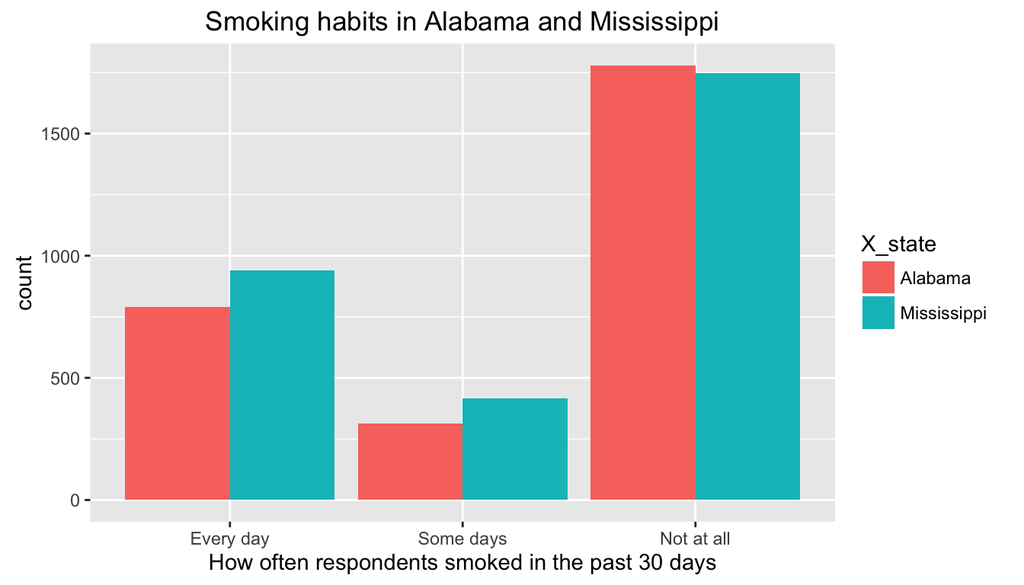

```r
smokdaydata = brfss2013[,c("smokday2","X_state")]
alabamasmokdaydata = smokdaydata[smokdaydata$X_state == "Alabama",]
filteralabamasd = na.omit(alabamasmokdaydata)
mississippismokdaydata = smokdaydata[smokdaydata$X_state == "Mississippi",]
filtermissisd = na.omit(mississippismokdaydata)
mialfiltersd = rbind(filteralabamasd,filtermissisd)
ggplot(data=mialfiltersd,aes(x=(smokday2),fill=X_state)) + geom_bar(position = "dodge") + xlab("How often respondents smoked in the past 30 days") + ggtitle("Smoking habits in Alabama and Mississippi")
```

As the graph suggests, people in Mississippi are more likely to smoke daily than those in Alabama. Accordingly, people in Alabama are more likely to not smoke at all.

```r
affmeds = brfss2013[,c("sex","medscost")]
maleaffmeds = affmeds[affmeds$sex == "Male",]
maleaffmedsyes = maleaffmeds[maleaffmeds$medscost == "Yes",]
filtermaleaffmedsy = na.omit(maleaffmedsyes)
filtermaleaffmeds = na.omit(maleaffmeds)
count(filtermaleaffmedsy)/count(filtermaleaffmeds)
```

```
##            n
## 1 0.06207106
```

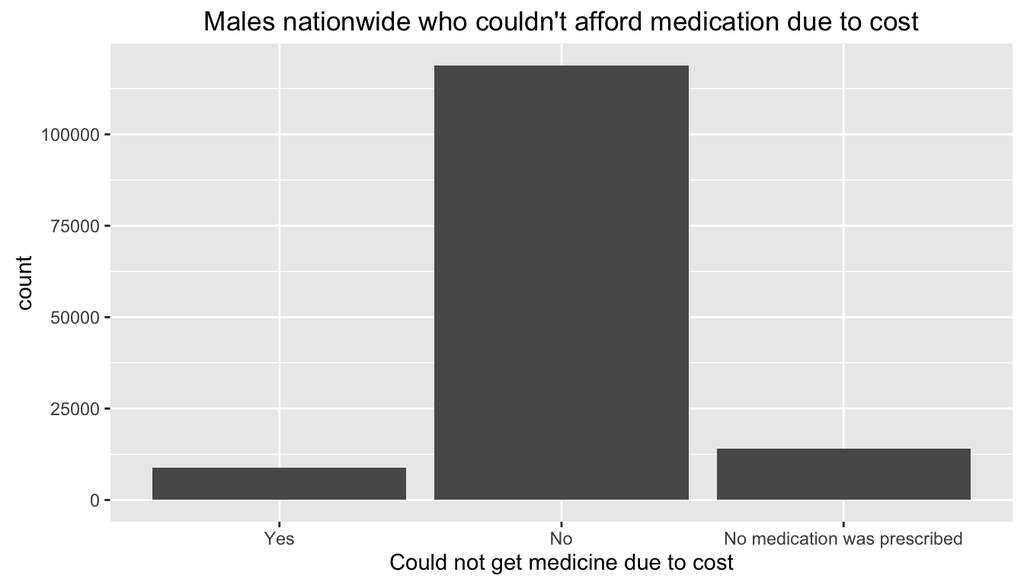

```r
ggplot(filtermaleaffmeds, aes(x=filtermaleaffmeds$medscost)) + geom_bar(position = "dodge") + xlab("Could not get medicine due to cost") + ggtitle("Males nationwide who couldn't afford medication due to cost")
```